# Project: Wrangling and Analyze Data

### Issue Q-4:

> - **Q-2:** Time stamps are not standard hence require conversion to standard format.

#### Define

> - For **Q-4**, we will need to convert the time stamps data to a standard time format.

#### Code

```python
twitter_archive_clean['timestamp'] = pd.to_datetime(twitter_archive_clean['timestamp'])
```

#### Test

```python
twitter_archive_clean.info()
```

```
<class 'pandas.core.frame.DataFrame'>
Int64Index: 2097 entries, 0 to 2355
Data columns (total 12 columns):
tweet_id              2097 non-null int64
timestamp             2097 non-null datetime64[ns]
source                2097 non-null object
text                  2097 non-null object
expanded_urls         2094 non-null object
rating_numerator      2097 non-null int64
rating_denominator    2097 non-null int64
name                  2097 non-null object
doggo                 2097 non-null object
floofer               2097 non-null object
pupper                2097 non-null object
puppo                 2097 non-null object
dtypes: datetime64[ns](1), int64(3), object(8)
memory usage: 213.0+ KB
```

### Issue Q-7:

> - **Q-7:** tweet_id contains data in numerical form which should be a string

#### Define:

> - For **Q-7**, we will have to convert data in tweet_id to string form

#### Code

```python
twitter_archive_clean['tweet_id'] = twitter_archive_clean['tweet_id'].astype(str)
```

### Test

```python
twitter_archive_clean.info()
```

```
<class 'pandas.core.frame.DataFrame'>
Int64Index: 2097 entries, 0 to 2355
Data columns (total 12 columns):
tweet_id              2097 non-null object
timestamp             2097 non-null datetime64[ns]
source                2097 non-null object
text                  2097 non-null object
expanded_urls         2094 non-null object
rating_numerator      2097 non-null int64
rating_denominator    2097 non-null int64
name                  2097 non-null object
doggo                 2097 non-null object
floofer               2097 non-null object
pupper                2097 non-null object
puppo                 2097 non-null object
dtypes: datetime64[ns](1), int64(2), object(9)
memory usage: 213.0+ KB
```

### Issue Q-5

> - **Q-5:** Data from text in the source column does not portray an exact source, rather it contains raw html

#### Define:

> - For **Q-5**, we intend to replace the data in the columns with the actual source data

#### Code

```python
twitter_archive_clean['source'].value_counts()
```

```
<a href="http://twitter.com/download/iphone" rel="nofollow">Twitter for iPhone</a>     1964
<a href="http://vine.co" rel="nofollow">Vine - Make a Scene</a>                          91
<a href="http://twitter.com" rel="nofollow">Twitter Web Client</a>                       31
<a href="https://about.twitter.com/products/tweetdeck" rel="nofollow">TweetDeck</a>      11
Name: source, dtype: int64
```

> - Since there are only 4 unique values, there is no need for looping code. We use replace

```python
# Replace all html link snippets with actual source data
twitter_archive_clean['source'] = twitter_archive_clean['source'].str.replace('<a href="http://twitter.com/download/iphone" rel="nofollow">Twitter for iPhone</a>', 'Twitter for iPhone')
twitter_archive_clean['source'] = twitter_archive_clean['source'].str.replace('<a href="http://vine.co" rel="nofollow">Vine - Make a Scene</a>','Vine - Make a Scene')
twitter_archive_clean['source'] = twitter_archive_clean['source'].str.replace('<a href="http://twitter.com" rel="nofollow">Twitter Web Client</a>','Twitter Web Client')
twitter_archive_clean['source'] = twitter_archive_clean['source'].str.replace('<a href="https://about.twitter.com/products/tweetdeck" rel="nofollow">TweetDeck</a>','TweetDeck')
```

#### Test

```python
twitter_archive_clean['source'].value_counts()
```

```
Twitter for iPhone     1964
Vine - Make a Scene      91
Twitter Web Client       31
TweetDeck                11
Name: source, dtype: int64
```

### Issue Q-2 and T-2:

> - **Q-2:** The representation of missing values as None rather than NaN is inappropriate.
> - **T-2:** The 4 dog columnsfor dog stages (doggo,floofer,pupper,puppo) need to be on the same column for dog stage.

#### Define:

> - For **Q-2**, We will remove all Nones to have a representation of missing values as NaN
> - For **T-2**, We will create a new column dog stage, which contains dog stage values in i column.

#### Code:

```python
#View the data in columns doggo, floofer, pupper and puppo
twitter_archive_clean[['doggo','floofer','pupper','puppo']].head(25).T
```

|  | 0 | 1 | 2 | 3 | 4 | 5 | 6 | 7 | 8 | 9 | ... | 15 | 16 | 17 | 18 | 20 | 21 | 22 | 23 | 24 | 25 |
| --- | --- | --- | --- | --- | --- | --- | --- | --- | --- | --- | --- | --- | --- | --- | --- | --- | --- | --- | --- | --- | --- |
| doggo | None | None | None | None | None | None | None | None | None | doggo | ... | None | None | None | None | None | None | None | None | None | None |
| floofer | None | None | None | None | None | None | None | None | None | None | ... | None | None | None | None | None | None | None | None | None | None |
| pupper | None | None | None | None | None | None | None | None | None | None | ... | None | None | None | None | None | None | None | None | None | None |
| puppo | None | None | None | None | None | None | None | None | None | None | ... | None | None | None | None | None | None | None | None | None | None |

4 rows × 25 columns

```python
# We create a new column dog_stages that combines the data in the 4 columns
twitter_archive_clean['dog_stage'] = (twitter_archive_clean.doggo +
                                    twitter_archive_clean.pupper +
                                    twitter_archive_clean.floofer + twitter_archive_clean.puppo)
```

```python
#View the combined dog_stages column
twitter_archive_clean[['dog_stage','doggo','floofer','pupper','puppo']].head(20).T
```

|  | 0 | 1 | 2 | 3 | 4 | 5 | 6 | 7 | 8 | 9 | 10 | 11 | 12 | 13 | 14 | 15 | 16 | 17 | 18 | 20 |
| --- | --- | --- | --- | --- | --- | --- | --- | --- | --- | --- | --- | --- | --- | --- | --- | --- | --- | --- | --- | --- |
| dog_stage | NoneNoneNoneNone | NoneNoneNoneNone | NoneNoneNoneNone | NoneNoneNoneNone | NoneNoneNoneNone | NoneNoneNoneNone | NoneNoneNoneNone | NoneNoneNoneNone | NoneNoneNoneNone | doggoNoneNoneNone | NoneNoneNoneNone | NoneNoneNoneNone | NoneNoneNonepuppo | NoneNoneNoneNone | NoneNoneNonepuppo | NoneNoneNoneNone | NoneNoneNoneNone | NoneNoneNoneNone | NoneNoneNoneNone | NoneNoneNoneNone |
| doggo | None | None | None | None | None | None | None | None | None | doggo | None | None | None | None | None | None | None | None | None | None |
| floofer | None | None | None | None | None | None | None | None | None | None | None | None | None | None | None | None | None | None | None | None |
| pupper | None | None | None | None | None | None | None | None | None | None | None | None | None | None | None | None | None | None | None | None |
| puppo | None | None | None | None | None | None | None | None | None | None | None | None | puppo | None | puppo | None | None | None | None | None |

```python
#Identify data to correct in the dog_stages field
twitter_archive_clean['dog_stage'].value_counts()
```

```
NoneNoneNoneNone        1761
NonepupperNoneNone       221
doggoNoneNoneNone         72
NoneNoneNonepuppo         23
NoneNoneflooferNone        9
doggopupperNoneNone        9
doggoNoneflooferNone       1
doggoNoneNonepuppo         1
Name: dog_stage, dtype: int64
```

```python
# Replacing data forms with the correct forms
twitter_archive_clean['dog_stage'] = twitter_archive_clean['dog_stage'].replace('NoneNoneNoneNone',np.nan)
twitter_archive_clean['dog_stage'] = twitter_archive_clean['dog_stage'].str.replace('NonepupperNoneNone','pupper')
twitter_archive_clean['dog_stage'] = twitter_archive_clean['dog_stage'].str.replace('doggoNoneNoneNone','doggo')
twitter_archive_clean['dog_stage'] = twitter_archive_clean['dog_stage'].str.replace('NoneNoneNonepuppo','puppo')
twitter_archive_clean['dog_stage'] = twitter_archive_clean['dog_stage'].str.replace('doggopupperNoneNone','doggo, pupper')
twitter_archive_clean['dog_stage'] = twitter_archive_clean['dog_stage'].str.replace('NoneNoneflooferNone','floofer')
twitter_archive_clean['dog_stage'] = twitter_archive_clean['dog_stage'].str.replace('doggoNoneNonepuppo','doggo, puppo')
twitter_archive_clean['dog_stage'] = twitter_archive_clean['dog_stage'].str.replace('doggoNoneflooferNone','doggo,floofer')
#replace remaining data 'None' with null NaN values
twitter_archive_clean.replace('None',np.nan,inplace=True)
#View dataforms that have been created
twitter_archive_clean['dog_stage'].value_counts()
```

```
pupper           221
doggo             72
puppo             23
floofer            9
doggo, pupper      9
doggo,floofer      1
doggo, puppo       1
Name: dog_stage, dtype: int64
```

```python
#twitter_archive_clean[twitter_archive_clean['dog_stage'] == 'doggo, pupper']['text'][1113]
# faulty indexes
#[460,531,575] = pupper
#[705] = doggo
#[956] = np.nan
#twitter_archive_clean[twitter_archive_clean['dog_stage'] == 'doggo,floofer']['text'][200]
#doggo floofer is a floofer
#twitter_archive_clean[twitter_archive_clean['dog_stage'] == 'doggo, puppo']['text'][191]
#doggo puppo is a puopo
```

[output not shown]

```python
#Replacings puppers
pup = [460,531,575]
for i in pup:
    twitter_archive_clean.loc[i,'dog_stage'] = 'pupper'
#replacing dogos
twitter_archive_clean.loc[705,'dog_stage'] = 'doggo'
#replacing nan
twitter_archive_clean.loc[956,'dog_stage'] = np.nan
#replacing floofer
twitter_archive_clean.loc[200,'dog_stage'] = 'floofer'
#replacing puppo
twitter_archive_clean.loc[191,'dog_stage'] = 'puppo'
```

#### Test

```python
twitter_archive_clean[['dog_stage','doggo','floofer','pupper','puppo']].head(20).T
```

|  | 0 | 1 | 2 | 3 | 4 | 5 | 6 | 7 | 8 | 9 | 10 | 11 | 12 | 13 | 14 | 15 | 16 | 17 | 18 | 20 |
| --- | --- | --- | --- | --- | --- | --- | --- | --- | --- | --- | --- | --- | --- | --- | --- | --- | --- | --- | --- | --- |
| dog_stage | NaN | NaN | NaN | NaN | NaN | NaN | NaN | NaN | NaN | doggo | NaN | NaN | puppo | NaN | puppo | NaN | NaN | NaN | NaN | NaN |
| doggo | NaN | NaN | NaN | NaN | NaN | NaN | NaN | NaN | NaN | doggo | NaN | NaN | NaN | NaN | NaN | NaN | NaN | NaN | NaN | NaN |
| floofer | NaN | NaN | NaN | NaN | NaN | NaN | NaN | NaN | NaN | NaN | NaN | NaN | NaN | NaN | NaN | NaN | NaN | NaN | NaN | NaN |
| pupper | NaN | NaN | NaN | NaN | NaN | NaN | NaN | NaN | NaN | NaN | NaN | NaN | NaN | NaN | NaN | NaN | NaN | NaN | NaN | NaN |
| puppo | NaN | NaN | NaN | NaN | NaN | NaN | NaN | NaN | NaN | NaN | NaN | NaN | puppo | NaN | puppo | NaN | NaN | NaN | NaN | NaN |

```python
twitter_archive_clean['dog_stage'].value_counts()
```

```
pupper           224
doggo             73
puppo             24
floofer           10
doggo, pupper      4
Name: dog_stage, dtype: int64
```

### Issue T-1 and Q-6:

> - **Q-6:** The texts contain urls
> - **T-1:** The numerators and denominators of dog ratings are in separate columns.

#### Define:

> - For **T-1**, we need to combine the data for the ratings.

```python
#To remove urls in the text
import re
refined_text = []
for string in twitter_archive_clean['text']:
    string_new = re.sub(r"\S*https?:\S*", "", string)
    refined_text.append(string_new)

print(len(twitter_archive_clean.text))
print(len(refined_text))
```

```
2097
2097
```

```python
# Create column for refined text
twitter_archive_clean['refined_text'] = refined_text
```

```python
twitter_archive_clean.sort_values(by = ['rating_denominator']).head().T
```

|  | 2335 | 516 | 0 | 1642 | 1641 |
| --- | --- | --- | --- | --- | --- |
| tweet_id | 666287406224695296 | 810984652412424192 | 892420643555336193 | 684097758874210310 | 684122891630342144 |
| timestamp | 2015-11-16 16:11:11 | 2016-12-19 23:06:23 | 2017-08-01 16:23:56 | 2016-01-04 19:43:10 | 2016-01-04 21:23:02 |
| source | Twitter for iPhone | Twitter for iPhone | Twitter for iPhone | Twitter for iPhone | Twitter for iPhone |
| text | This is an Albanian 3 1/2 legged Episcopalian... | Meet Sam. She smiles 24/7 &amp; secretly aspir... | This is Phineas. He's a mystical boy. Only eve... | Say hello to Lupe. This is how she sleeps. 10/... | Heartwarming scene of two pups that want nothi... |
| expanded_urls | https://twitter.com/dog_rates/status/666287406... | https://www.gofundme.com/sams-smile,https://tw... | https://twitter.com/dog_rates/status/892420643... | https://twitter.com/dog_rates/status/684097758... | https://twitter.com/dog_rates/status/684122891... |
| rating_numerator | 1 | 24 | 13 | 10 | 11 |
| rating_denominator | 2 | 7 | 10 | 10 | 10 |
| name | an | Sam | Phineas | Lupe | NaN |
| doggo | NaN | NaN | NaN | NaN | NaN |
| floofer | NaN | NaN | NaN | NaN | NaN |
| pupper | NaN | NaN | NaN | NaN | NaN |
| puppo | NaN | NaN | NaN | NaN | NaN |
| dog_stage | NaN | NaN | NaN | NaN | NaN |
| refined_text | This is an Albanian 3 1/2 legged Episcopalian... | Meet Sam. She smiles 24/7 &amp; secretly aspir... | This is Phineas. He's a mystical boy. Only eve... | Say hello to Lupe. This is how she sleeps. 10/... | Heartwarming scene of two pups that want nothi... |

```python
twitter_archive_clean['refined_text'][0]
```

```
"This is Phineas. He's a mystical boy. Only ever appears in the hole of a donut. 13/10 "
```

```python
!pip install nums_from_string
```

```python
import nums_from_string

valid_numbers = []

for string in twitter_archive_clean['refined_text']:
    valid_numbers.append(nums_from_string.get_nums(string))
print(valid_numbers)
```

```
[[13, 10], [13, 10], [12, 10], [13, 10], [12, 10], [13, 10], [13, 10], [13, 10], [13, 10], [14, 10], [13, 10], [13, 10], [13, 10], [12, 10], [13, 10], [13, 10], [12, 10], [13, 10], [13, 10], [12, 10], [13, 10], [14, 10], [13, 10], [13, 10], [12, 10], [13, 10], [13, 10], [13, 10], [12, 10], [13, 10],…
```

```python
number_of_numbers = []
for i in valid_numbers:
    len_num_i = len(i)
    number_of_numbers.append(len_num_i)
number_of_numbers= pd.DataFrame(number_of_numbers)
number_of_numbers[0].value_counts()
```

```
2    1973
3      82
4      35
5       6
6       1
Name: 0, dtype: int64
```

```python
number_of_numbers.sort_values(by = [0],ascending =False).head(20).T
```

|  | 1759 | 1076 | 1551 | 2076 | 1245 | 208 | 900 | 562 | 563 | 1307 | 1023 | 2047 | 1318 | 1278 | 797 | 1757 | 1375 | 1387 | 1294 | 1005 |
| --- | --- | --- | --- | --- | --- | --- | --- | --- | --- | --- | --- | --- | --- | --- | --- | --- | --- | --- | --- | --- |
| 0 | 6 | 5 | 5 | 5 | 5 | 5 | 5 | 4 | 4 | 4 | 4 | 4 | 4 | 4 | 4 | 4 | 4 | 4 | 4 | 4 |

```python
twitter_archive_clean['refined_text'][2010]
```

```
'10/10 for dog. 7/10 for cat. 12/10 for human. Much skill. Would pet all '
```

```python
twitter_archive_clean['refined_text'][1897]
```

```
'Meet Rufio. He is unaware of the pink legless pupper wrapped around him. Might want to get that checked 10/10 &amp; 4/10 '
```

```python
import re
valid_ratings= []
for string in twitter_archive_clean['refined_text']:
    Act_ratings = re.findall('\d?\d/\d\d?',string)
    valid_ratings.append(Act_ratings)

number_of_ratings = []
for i in valid_ratings:
    size = len(i)
    number_of_ratings.append(size)

number_of_ratings[1759]
```

```
3
```

> Some tweets contain more that one rating hence require that the data be corrected

```python
#We append lengths column to enable checkinh of fields of length greater than 2
twitter_archive_clean['number_of_numbers'] = number_of_numbers
twitter_archive_clean['number_of_ratings'] = number_of_ratings
index = list(range(len(number_of_numbers)))
twitter_archive_clean['index_column'] = index
twitter_archive_clean.head().T
```

|  | 0 | 1 | 2 | 3 | 4 |
| --- | --- | --- | --- | --- | --- |
| tweet_id | 892420643555336193 | 892177421306343426 | 891815181378084864 | 891689557279858688 | 891327558926688256 |
| timestamp | 2017-08-01 16:23:56 | 2017-08-01 00:17:27 | 2017-07-31 00:18:03 | 2017-07-30 15:58:51 | 2017-07-29 16:00:24 |
| source | Twitter for iPhone | Twitter for iPhone | Twitter for iPhone | Twitter for iPhone | Twitter for iPhone |
| text | This is Phineas. He's a mystical boy. Only eve... | This is Tilly. She's just checking pup on you.... | This is Archie. He is a rare Norwegian Pouncin... | This is Darla. She commenced a snooze mid meal... | This is Franklin. He would like you to stop ca... |
| expanded_urls | https://twitter.com/dog_rates/status/892420643... | https://twitter.com/dog_rates/status/892177421... | https://twitter.com/dog_rates/status/891815181... | https://twitter.com/dog_rates/status/891689557... | https://twitter.com/dog_rates/status/891327558... |
| rating_numerator | 13 | 13 | 12 | 13 | 12 |
| rating_denominator | 10 | 10 | 10 | 10 | 10 |
| name | Phineas | Tilly | Archie | Darla | Franklin |
| doggo | NaN | NaN | NaN | NaN | NaN |
| floofer | NaN | NaN | NaN | NaN | NaN |
| pupper | NaN | NaN | NaN | NaN | NaN |
| puppo | NaN | NaN | NaN | NaN | NaN |
| dog_stage | NaN | NaN | NaN | NaN | NaN |
| refined_text | This is Phineas. He's a mystical boy. Only eve... | This is Tilly. She's just checking pup on you.... | This is Archie. He is a rare Norwegian Pouncin... | This is Darla. She commenced a snooze mid meal... | This is Franklin. He would like you to stop ca... |
| number_of_numbers | 2 | 2 | 2 | 2 | 2 |
| number_of_ratings | 1 | 1 | 1 | 1 | 1 |
| index_column | 0 | 1 | 2 | 3 | 4 |

```python
index[2096]
```

```
2096
```

```python
# This code uses index to loop the texts with more than one rating and compare the correct rating
#to the rating in the columns in order to ensure wrong extraxtions are replaced.
for i in twitter_archive_clean.index:
    if twitter_archive_clean.number_of_numbers[i] > 2 & twitter_archive_clean.number_of_ratings[i] > 1:
        print(f'For index {i} ',end ='')
        print(f'of length {twitter_archive_clean.number_of_numbers[i]}, the text is:', end ='')
        print(f'contains Num:{twitter_archive_clean.rating_numerator[i]} and Denom: {twitter_archive_clean.rating_denominator[i]}.')
        print(twitter_archive_clean.refined_text[i])
        correct_numerator = input('Correct numerator:')
        correct_denominator = input('Correct_denominator:')
        twitter_archive_clean.loc[i,'rating_numerator'] = correct_numerator
        twitter_archive_clean.loc[i,'rating_denominator'] = correct_denominator
```

> - With ratings corrected, we may now combine the ratings columns

```python
twitter_archive_clean[twitter_archive_clean.rating_numerator == 0].rating_numerator.T
```

```
315    0
Name: rating_numerator, dtype: int64
```

```python
print(twitter_archive_clean.refined_text[315])
```

```
When you're so blinded by your systematic plagiarism that you forget what day it is. 0/10
```

> Zero numerators are not valid ratings, hence drop

```python
twitter_archive_clean.drop([315],axis = 0, inplace =True)
```

```python
twitter_archive_clean[twitter_archive_clean.rating_denominator == 0].rating_denominator.T
```

```
Series([], Name: rating_denominator, dtype: int64)
```

> No zero numerators and denominators, hence free to combine.

```python
twitter_archive_clean['rating_fraction'] = pd.to_numeric(twitter_archive_clean.rating_numerator)/pd.to_numeric(twitter_archive_clean.rating_denominator)
```

#### Test:

```python
twitter_archive_clean.head().T
```

|  | 0 | 1 | 2 | 3 | 4 |
| --- | --- | --- | --- | --- | --- |
| tweet_id | 892420643555336193 | 892177421306343426 | 891815181378084864 | 891689557279858688 | 891327558926688256 |
| timestamp | 2017-08-01 16:23:56 | 2017-08-01 00:17:27 | 2017-07-31 00:18:03 | 2017-07-30 15:58:51 | 2017-07-29 16:00:24 |
| source | Twitter for iPhone | Twitter for iPhone | Twitter for iPhone | Twitter for iPhone | Twitter for iPhone |
| text | This is Phineas. He's a mystical boy. Only eve... | This is Tilly. She's just checking pup on you.... | This is Archie. He is a rare Norwegian Pouncin... | This is Darla. She commenced a snooze mid meal... | This is Franklin. He would like you to stop ca... |
| expanded_urls | https://twitter.com/dog_rates/status/892420643... | https://twitter.com/dog_rates/status/892177421... | https://twitter.com/dog_rates/status/891815181... | https://twitter.com/dog_rates/status/891689557... | https://twitter.com/dog_rates/status/891327558... |
| rating_numerator | 13 | 13 | 12 | 13 | 12 |
| rating_denominator | 10 | 10 | 10 | 10 | 10 |
| name | Phineas | Tilly | Archie | Darla | Franklin |
| doggo | NaN | NaN | NaN | NaN | NaN |
| floofer | NaN | NaN | NaN | NaN | NaN |
| pupper | NaN | NaN | NaN | NaN | NaN |
| puppo | NaN | NaN | NaN | NaN | NaN |
| dog_stage | NaN | NaN | NaN | NaN | NaN |
| refined_text | This is Phineas. He's a mystical boy. Only eve... | This is Tilly. She's just checking pup on you.... | This is Archie. He is a rare Norwegian Pouncin... | This is Darla. She commenced a snooze mid meal... | This is Franklin. He would like you to stop ca... |
| number_of_numbers | 2 | 2 | 2 | 2 | 2 |
| number_of_ratings | 1 | 1 | 1 | 1 | 1 |
| index_column | 0 | 1 | 2 | 3 | 4 |
| rating_fraction | 1.3 | 1.3 | 1.2 | 1.3 | 1.2 |

### Issue T-4 and T-5:

> - **T-4:** Column titles are not descriptive for image_predictions data
> - **T-5:** Records differed for image_predictions and archive data

```python
image_predictions_clean.head().T
```

|  | 0 | 1 | 2 | 3 | 4 |
| --- | --- | --- | --- | --- | --- |
| tweet_id | 666020888022790149 | 666029285002620928 | 666033412701032449 | 666044226329800704 | 666049248165822465 |
| jpg_url | https://pbs.twimg.com/media/CT4udn0WwAA0aMy.jpg | https://pbs.twimg.com/media/CT42GRgUYAA5iDo.jpg | https://pbs.twimg.com/media/CT4521TWwAEvMyu.jpg | https://pbs.twimg.com/media/CT5Dr8HUEAA-lEu.jpg | https://pbs.twimg.com/media/CT5IQmsXIAAKY4A.jpg |
| img_num | 1 | 1 | 1 | 1 | 1 |
| p1 | Welsh_springer_spaniel | redbone | German_shepherd | Rhodesian_ridgeback | miniature_pinscher |
| p1_conf | 0.465074 | 0.506826 | 0.596461 | 0.408143 | 0.560311 |
| p1_dog | True | True | True | True | True |
| p2 | collie | miniature_pinscher | malinois | redbone | Rottweiler |
| p2_conf | 0.156665 | 0.0741917 | 0.138584 | 0.360687 | 0.243682 |
| p2_dog | True | True | True | True | True |
| p3 | Shetland_sheepdog | Rhodesian_ridgeback | bloodhound | miniature_pinscher | Doberman |
| p3_conf | 0.0614285 | 0.07201 | 0.116197 | 0.222752 | 0.154629 |
| p3_dog | True | True | True | True | True |

```python
image_predictions_clean.columns
```

```
Index(['tweet_id', 'jpg_url', 'img_num', 'p1', 'p1_conf', 'p1_dog', 'p2',
       'p2_conf', 'p2_dog', 'p3', 'p3_conf', 'p3_dog'],
      dtype='object')
```

```python
new_columns = ['tweet_id', 'image_link', 'most_confident_prediction', 'prediction_1',
               'prediction_1_confidence', 'prediction_1_isdog', 'prediction_2',
               'prediction_2_confidence', 'prediction_2_isdog', 'prediction_3',
               'prediction_3_confidence', 'prediction_3_isdog']
image_predictions_clean.columns = new_columns
image_predictions_clean.columns
```

```
Index(['tweet_id', 'image_link', 'most_confident_prediction', 'prediction_1',
       'prediction_1_confidence', 'prediction_1_isdog', 'prediction_2',
       'prediction_2_confidence', 'prediction_2_isdog', 'prediction_3',
       'prediction_3_confidence', 'prediction_3_isdog'],
      dtype='object')
```

```python
len(image_predictions_clean.tweet_id) == len(twitter_archive_clean.tweet_id)
```

```
False
```

```python
print(len(image_predictions_clean.tweet_id))
print(len(twitter_archive_clean.tweet_id))
print(len(tweeter_api_clean.tweet_id))
```

```
2075
2096
2327
```

> - The some values in the twitter archive data do not have image prediction values. we therefore need to select values that have image predictions.
> - Image predictions is the least data length

```python
tweeter_api_clean.info()
```

```
<class 'pandas.core.frame.DataFrame'>
RangeIndex: 2327 entries, 0 to 2326
Data columns (total 3 columns):
tweet_id          2327 non-null int64
retweet_count     2327 non-null int64
favorite_count    2327 non-null int64
dtypes: int64(3)
memory usage: 54.6 KB
```

```python
#ensure twwet ids are in text
twitter_archive_clean['tweet_id'] = twitter_archive_clean['tweet_id'].astype(str)
image_predictions_clean['tweet_id'] = image_predictions_clean['tweet_id'].astype(str)
tweeter_api_clean['tweet_id'] = tweeter_api_clean['tweet_id'].astype(str)
```

## Storing Data

Save gathered, assessed, and cleaned master dataset to a CSV file named "twitter_archive_master.csv".

```python
image_and_archive = pd.merge(left = image_predictions_clean, right=twitter_archive_clean, how='inner', on='tweet_id')
```

```python
image_and_archive.info()
```

```
<class 'pandas.core.frame.DataFrame'>
Int64Index: 1970 entries, 0 to 1969
Data columns (total 29 columns):
tweet_id                     1970 non-null object
image_link                   1970 non-null object
most_confident_prediction    1970 non-null int64
prediction_1                 1970 non-null object
prediction_1_confidence      1970 non-null float64
prediction_1_isdog           1970 non-null bool
prediction_2                 1970 non-null object
prediction_2_confidence      1970 non-null float64
prediction_2_isdog           1970 non-null bool
prediction_3                 1970 non-null object
prediction_3_confidence      1970 non-null float64
prediction_3_isdog           1970 non-null bool
timestamp                    1970 non-null datetime64[ns]
source                       1970 non-null object
text                         1970 non-null object
expanded_urls                1970 non-null object
rating_numerator             1970 non-null int64
rating_denominator           1970 non-null int64
name                         1447 non-null object
doggo                        73 non-null object
floofer                      8 non-null object
pupper                       209 non-null object
puppo                        23 non-null object
dog_stage                    302 non-null object
refined_text                 1970 non-null object
number_of_numbers            1718 non-null float64
number_of_ratings            1970 non-null int64
index_column                 1970 non-null int64
rating_fraction              1970 non-null float64
dtypes: bool(3), datetime64[ns](1), float64(5), int64(5), object(15)
memory usage: 421.3+ KB
```

```python
image_and_archive_and_api = pd.merge(left = image_and_archive, right=tweeter_api_clean, how='inner', on='tweet_id')
```

```python
image_and_archive_and_api.info()
```

```
<class 'pandas.core.frame.DataFrame'>
Int64Index: 1962 entries, 0 to 1961
Data columns (total 31 columns):
tweet_id                     1962 non-null object
image_link                   1962 non-null object
most_confident_prediction    1962 non-null int64
prediction_1                 1962 non-null object
prediction_1_confidence      1962 non-null float64
prediction_1_isdog           1962 non-null bool
prediction_2                 1962 non-null object
prediction_2_confidence      1962 non-null float64
prediction_2_isdog           1962 non-null bool
prediction_3                 1962 non-null object
prediction_3_confidence      1962 non-null float64
prediction_3_isdog           1962 non-null bool
timestamp                    1962 non-null datetime64[ns]
source                       1962 non-null object
text                         1962 non-null object
expanded_urls                1962 non-null object
rating_numerator             1962 non-null int64
rating_denominator           1962 non-null int64
name                         1440 non-null object
doggo                        72 non-null object
floofer                      8 non-null object
pupper                       209 non-null object
puppo                        23 non-null object
dog_stage                    301 non-null object
refined_text                 1962 non-null object
number_of_numbers            1710 non-null float64
number_of_ratings            1962 non-null int64
index_column                 1962 non-null int64
rating_fraction              1962 non-null float64
retweet_count                1962 non-null int64
favorite_count               1962 non-null int64
dtypes: bool(3), datetime64[ns](1), float64(5), int64(7), object(15)
memory usage: 450.3+ KB
```

```python
image_and_archive_and_api.columns
```

```
Index(['tweet_id', 'image_link', 'most_confident_prediction', 'prediction_1',
       'prediction_1_confidence', 'prediction_1_isdog', 'prediction_2',
       'prediction_2_confidence', 'prediction_2_isdog', 'prediction_3',
       'prediction_3_confidence', 'prediction_3_isdog', 'timestamp', 'source',
       'text', 'expanded_urls', 'rating_numerator', 'rating_denominator',
       'name', 'doggo', 'floofer', 'pupper', 'puppo', 'dog_stage',
       'refined_text', 'number_of_numbers', 'number_of_ratings',
       'index_column', 'rating_fraction', 'retweet_count', 'favorite_count'],
      dtype='object')
```

```python
image_and_archive_and_api.drop(columns = ['text','rating_numerator','rating_denominator','doggo', 'floofer', 'pupper', 'puppo','number_of_numbers', 'number_of_ratings','index_column'],inplace = True)
image_and_archive_and_api.rename(columns = {'name':'dog_name'}, inplace = True)
```

```python
image_and_archive_and_api.columns
```

```
Index(['tweet_id', 'image_link', 'most_confident_prediction', 'prediction_1',
       'prediction_1_confidence', 'prediction_1_isdog', 'prediction_2',
       'prediction_2_confidence', 'prediction_2_isdog', 'prediction_3',
       'prediction_3_confidence', 'prediction_3_isdog', 'timestamp', 'source',
       'expanded_urls', 'dog_name', 'dog_stage', 'refined_text',
       'rating_fraction', 'retweet_count', 'favorite_count'],
      dtype='object')
```

```python
master_data_set = image_and_archive_and_api[['tweet_id','timestamp','refined_text','dog_name', 'dog_stage',
 'image_link','expanded_urls','source', 'prediction_1_confidence','prediction_2_confidence','prediction_3_confidence','most_confident_prediction',
 'prediction_1','prediction_2','prediction_3', 'prediction_1_isdog', 'prediction_2_isdog', 'prediction_3_isdog', 'rating_fraction', 'retweet_count', 'favorite_count']]
master_data_set.head().T
```

|  | 0 | 1 | 2 | 3 | 4 |
| --- | --- | --- | --- | --- | --- |
| tweet_id | 666020888022790149 | 666029285002620928 | 666033412701032449 | 666044226329800704 | 666049248165822465 |
| timestamp | 2015-11-15 22:32:08 | 2015-11-15 23:05:30 | 2015-11-15 23:21:54 | 2015-11-16 00:04:52 | 2015-11-16 00:24:50 |
| refined_text | Here we have a Japanese Irish Setter. Lost eye... | This is a western brown Mitsubishi terrier. Up... | Here is a very happy pup. Big fan of well-main... | This is a purebred Piers Morgan. Loves to Netf... | Here we have a 1949 1st generation vulpix. Enj... |
| dog_name | NaN | a | a | a | NaN |
| dog_stage | NaN | NaN | NaN | NaN | NaN |
| image_link | https://pbs.twimg.com/media/CT4udn0WwAA0aMy.jpg | https://pbs.twimg.com/media/CT42GRgUYAA5iDo.jpg | https://pbs.twimg.com/media/CT4521TWwAEvMyu.jpg | https://pbs.twimg.com/media/CT5Dr8HUEAA-lEu.jpg | https://pbs.twimg.com/media/CT5IQmsXIAAKY4A.jpg |
| expanded_urls | https://twitter.com/dog_rates/status/666020888... | https://twitter.com/dog_rates/status/666029285... | https://twitter.com/dog_rates/status/666033412... | https://twitter.com/dog_rates/status/666044226... | https://twitter.com/dog_rates/status/666049248... |
| source | Twitter for iPhone | Twitter for iPhone | Twitter for iPhone | Twitter for iPhone | Twitter for iPhone |
| prediction_1_confidence | 0.465074 | 0.506826 | 0.596461 | 0.408143 | 0.560311 |
| prediction_2_confidence | 0.156665 | 0.0741917 | 0.138584 | 0.360687 | 0.243682 |
| prediction_3_confidence | 0.0614285 | 0.07201 | 0.116197 | 0.222752 | 0.154629 |
| most_confident_prediction | 1 | 1 | 1 | 1 | 1 |
| prediction_1 | Welsh_springer_spaniel | redbone | German_shepherd | Rhodesian_ridgeback | miniature_pinscher |
| prediction_2 | collie | miniature_pinscher | malinois | redbone | Rottweiler |
| prediction_3 | Shetland_sheepdog | Rhodesian_ridgeback | bloodhound | miniature_pinscher | Doberman |
| prediction_1_isdog | True | True | True | True | True |
| prediction_2_isdog | True | True | True | True | True |
| prediction_3_isdog | True | True | True | True | True |
| rating_fraction | 0.8 | 0.7 | 0.9 | 0.6 | 0.5 |
| retweet_count | 419 | 39 | 36 | 114 | 36 |
| favorite_count | 2282 | 112 | 100 | 245 | 88 |

```python
master_data_set.to_csv('twitter_archive_master.csv',index=False, encoding = 'utf-8')
```

## Analyzing and Visualizing Data

In this section, we analyze and visualize your wrangled data with the following focus quaetions:

> > 1. What is the most popular dog name?
> > 2. What is the most popular dog stage?
> > 3. What is the most accurate prediction algorithm and what might influence the algorithms confidence.
> > 4. What sources do the algorithms find most confidence when predicting.

```python
df = pd.read_csv('twitter_archive_master.csv')
df.head().T
```

|  | 0 | 1 | 2 | 3 | 4 |
| --- | --- | --- | --- | --- | --- |
| tweet_id | 666020888022790149 | 666029285002620928 | 666033412701032449 | 666044226329800704 | 666049248165822465 |
| timestamp | 2015-11-15 22:32:08 | 2015-11-15 23:05:30 | 2015-11-15 23:21:54 | 2015-11-16 00:04:52 | 2015-11-16 00:24:50 |
| refined_text | Here we have a Japanese Irish Setter. Lost eye... | This is a western brown Mitsubishi terrier. Up... | Here is a very happy pup. Big fan of well-main... | This is a purebred Piers Morgan. Loves to Netf... | Here we have a 1949 1st generation vulpix. Enj... |
| dog_name | NaN | a | a | a | NaN |
| dog_stage | NaN | NaN | NaN | NaN | NaN |
| image_link | https://pbs.twimg.com/media/CT4udn0WwAA0aMy.jpg | https://pbs.twimg.com/media/CT42GRgUYAA5iDo.jpg | https://pbs.twimg.com/media/CT4521TWwAEvMyu.jpg | https://pbs.twimg.com/media/CT5Dr8HUEAA-lEu.jpg | https://pbs.twimg.com/media/CT5IQmsXIAAKY4A.jpg |
| expanded_urls | https://twitter.com/dog_rates/status/666020888... | https://twitter.com/dog_rates/status/666029285... | https://twitter.com/dog_rates/status/666033412... | https://twitter.com/dog_rates/status/666044226... | https://twitter.com/dog_rates/status/666049248... |
| source | Twitter for iPhone | Twitter for iPhone | Twitter for iPhone | Twitter for iPhone | Twitter for iPhone |
| prediction_1_confidence | 0.465074 | 0.506826 | 0.596461 | 0.408143 | 0.560311 |
| prediction_2_confidence | 0.156665 | 0.0741917 | 0.138584 | 0.360687 | 0.243682 |
| prediction_3_confidence | 0.0614285 | 0.07201 | 0.116197 | 0.222752 | 0.154629 |
| most_confident_prediction | 1 | 1 | 1 | 1 | 1 |
| prediction_1 | Welsh_springer_spaniel | redbone | German_shepherd | Rhodesian_ridgeback | miniature_pinscher |
| prediction_2 | collie | miniature_pinscher | malinois | redbone | Rottweiler |
| prediction_3 | Shetland_sheepdog | Rhodesian_ridgeback | bloodhound | miniature_pinscher | Doberman |
| prediction_1_isdog | True | True | True | True | True |
| prediction_2_isdog | True | True | True | True | True |
| prediction_3_isdog | True | True | True | True | True |
| rating_fraction | 0.8 | 0.7 | 0.9 | 0.6 | 0.5 |
| retweet_count | 419 | 39 | 36 | 114 | 36 |
| favorite_count | 2282 | 112 | 100 | 245 | 88 |

```python
# 1. Most popular dog name
df.groupby('dog_name').mean()['favorite_count'].sort_values(ascending=False).head(10)
```

```
dog_name
Stephan    111028.0
Jamesy     108430.0
Duddles     92431.0
Aja         68992.0
Lilly       62189.0
Canela      59937.0
Pipsy       42108.0
Barney      41021.0
such        40532.0
Alfy        38988.0
Name: favorite_count, dtype: float64
```

```python
#2. Most popular dog stage
df.groupby('dog_stage').mean()['favorite_count'].sort_values(ascending=False).head(10)
```

```
dog_stage
doggo, pupper    21173.666667
puppo            20451.086957
doggo            17353.126984
floofer          11620.500000
pupper            6257.950980
Name: favorite_count, dtype: float64
```

```python
#3. Overal most confident prediction algorithm
df.groupby(['most_confident_prediction']).mean()[['prediction_1_confidence','prediction_2_confidence','prediction_3_confidence']]
```

| most_confident_prediction | prediction_1_confidence | prediction_2_confidence | prediction_3_confidence |
| --- | --- | --- | --- |
| 1 | 0.571897 | 0.140588 | 0.062901 |
| 2 | 0.703956 | 0.108784 | 0.049031 |
| 3 | 0.759030 | 0.087314 | 0.037930 |
| 4 | 0.815534 | 0.059804 | 0.028127 |

```python
#4. Source of most confident images predicted
df.groupby(['source']).mean()['most_confident_prediction']
```

```
source
TweetDeck             1.200000
Twitter Web Client    1.107143
Twitter for iPhone    1.202703
Name: most_confident_prediction, dtype: float64
```

### Visualization

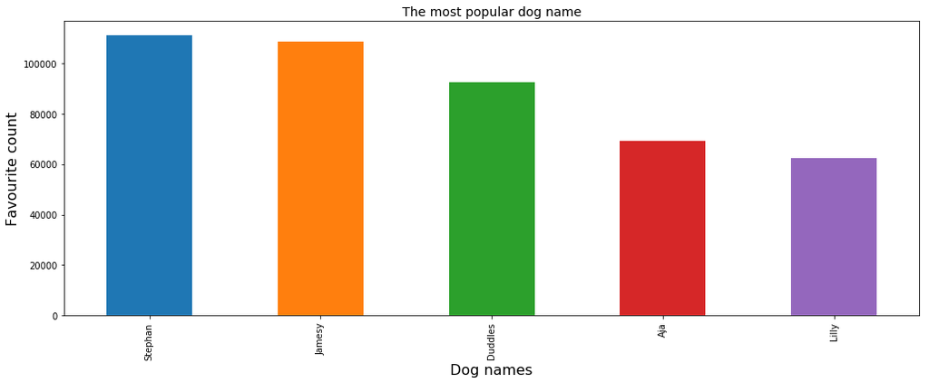

```python
# 1. Most popular dog name
plt.figure(figsize = (17,6))
df.groupby('dog_name').mean()['favorite_count'].sort_values(ascending=False).head(5).plot.bar()
plt.title("The most popular dog name",fontsize = 14)
plt.xlabel("Dog names",fontsize = 16);
plt.ylabel("Favourite count",fontsize = 16);
```

```python
#2. Most popular dog stage
df.groupby('dog_stage').mean()['favorite_count'].sort_values(ascending=False).head(10)
```

```
dog_stage
doggo, pupper    21173.666667
puppo            20451.086957
doggo            17353.126984
floofer          11620.500000
pupper            6257.950980
Name: favorite_count, dtype: float64
```

```python
#let's extract the sample image of most popular dog
popular_dog_stage_img = df[df['dog_stage'] == 'doggo, pupper'].sort_values(by = 'favorite_count',ascending = False)['image_link']
# extract just the image url (jpg_url), breed and favorite_count columns
#popular_dog_stage_img = popular_dog_stage_img[['dog_stage','favorite_count','image_link']][0:5]
# view
popular_dog_stage_img.loc[1134]
```

```
'https://pbs.twimg.com/media/CiyHLocU4AI2pJu.jpg'
```

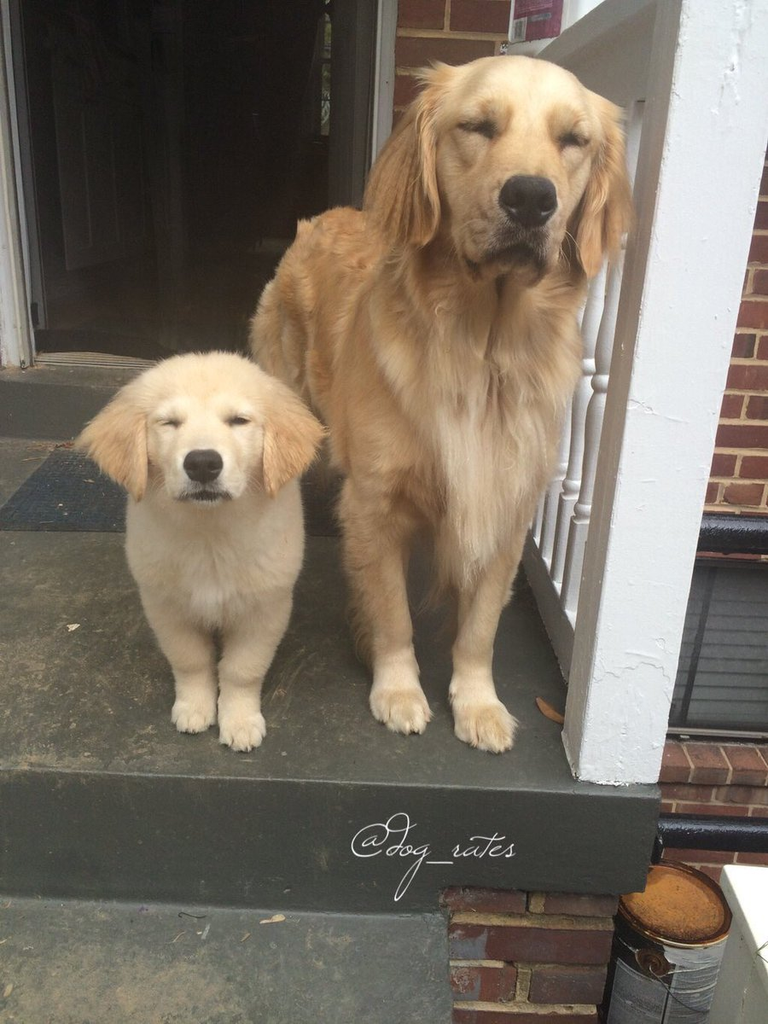

```python
#get the most popular by favorite count and view
popular_dog_stage_img = popular_dog_stage_img.loc[1134]
popular_dog_stage_img
# Doggo,puppo
Image(popular_dog_stage_img)
```